# Phishing Detection - Scenario 3: Stepwise vs Lasso vs Elastic-Net

```r
library(tidyverse)
library(caret)
library(glmnet)
library(MASS, exclude = "select")
library(yardstick)
library(knitr)
library(digest)

set.seed(2026)

ARTIFACTS <- "scenario_3/artifacts"
dir.create(ARTIFACTS, recursive = TRUE, showWarnings = FALSE)
GLMNET_LAMBDA_MIN_RATIO <- 1e-3
STEPWISE_GLM_MAXIT <- 100L
```

# 1. Scenario & Hypothesis

Scenario 2 fixed the predictor pool and asked which **model family** extracts more signal. Scenario 3 holds a single linear classifier (logistic regression) constant and asks which **feature-selection method** keeps the most compact predictor set without losing predictive power.

We pick **bidirectional stepwise** (`MASS::stepAIC`, `direction = "both"`) for the algorithmic side because it reconsiders previously-included terms instead of locking decisions in pure forward / backward variants. For the embedded pair we pick **Lasso (α = 1)** and **Elastic-Net (α = 0.5)**.

The primary classification task is the same first-line deployment case as the EDA and Scenario 2 motivation, the **Lexical** phishing detection. FullLite remains a secondary fallback benchmark so if URL-only is not enough and we have to inspect trust / behaviour signals as well, then we want the smallest combined-tier filter that preserves the operating quality.

**H2** *On the Lexical predictor pool, at least one feature-selection method can produce a compact deployable URL filter with strong held-out operating quality.*

| # | Criterion | Threshold |
| --- | --- | --- |
| C1 | Sparsity | at least one FS method keeps **<= 9 / 13** lexical predictors (>= 30% reduction) |
| C2 | Ranking quality | held-out **AUC >= 0.95** |
| C3 | Operating point | held-out **Sensitivity >= 0.94** and **Specificity >= 0.75** at threshold 0.5 |

We evaluate this on the same 80/20 split as Scenario 2 by comparing the three selected feature-selection methods: bidirectional stepwise, lasso and elastic-net.

# 2. Data Loading

```r
dataset_path <- if (file.exists("PhiUSIIL_Phishing_URL_Dataset.csv")) {
  "PhiUSIIL_Phishing_URL_Dataset.csv"
} else if (file.exists("../PhiUSIIL_Phishing_URL_Dataset.csv")) {
  "../PhiUSIIL_Phishing_URL_Dataset.csv"
} else stop("PhiUSIIL_Phishing_URL_Dataset.csv not found")

raw <- read_csv(dataset_path, show_col_types = FALSE) %>%
  rename_with(~ str_remove(.x, "^\ufeff"))
cat("Loaded", nrow(raw), "rows,", ncol(raw), "columns.\n")
```

```
Loaded 235795 rows, 56 columns.
```

## 2.1 EDA exclusions and FullLite tier

Same exclusions as in Scenario 2.

```r
ID_COLS          <- c("FILENAME", "URL", "Domain", "TLD", "Title")
SCORES           <- c("URLSimilarityIndex", "TLDLegitimateProb", "URLCharProb",
                      "DomainTitleMatchScore", "URLTitleMatchScore")
REDUNDANT_BINARY <- "HasObfuscation"
RATIOS           <- c("LetterRatioInURL", "DegitRatioInURL",
                      "ObfuscationRatio", "SpacialCharRatioInURL")
LEAKY_BEHAVIOR   <- c("LineOfCode", "NoOfExternalRef", "NoOfImage",
                      "NoOfSelfRef", "NoOfJS", "NoOfCSS")
EXCLUDE_COLS     <- c(ID_COLS, SCORES, REDUNDANT_BINARY, RATIOS, LEAKY_BEHAVIOR)

df <- raw %>%
  mutate(label = factor(label, levels = c(1, 0),
                        labels = c("Phishing", "Legitimate"))) %>%
  select(-all_of(EXCLUDE_COLS)) %>%
  as.data.frame()

cat("Feature matrix after exclusions:", ncol(df) - 1, "predictors.\n")
```

```
Feature matrix after exclusions: 34 predictors.
```

# 3. Modelling Setup

## 3.1 Stratified sub-sampling and split

Identical to Scenario 2 3.1-3.2 for parity. The 30k stratified subsample (15k / 15k) is inherited from Scenario 2’s SVM-driven budget. For Scenario 3 we keep it so the reduced-fit AUCs in the Lexical H2 check (Section 5) can be compared directly to LogReg-Ridge from Scenario 2 without a sample-size confound.

```r
N_SUB <- 30000
df_sub <- df %>%
  group_by(label) %>%
  slice_sample(n = N_SUB / 2) %>%
  ungroup() %>%
  as.data.frame()

idx <- createDataPartition(df_sub$label, p = 0.8, list = FALSE) %>%
  as.vector()
train_raw <- df_sub %>% slice(idx)
test_raw <- df_sub %>% slice(-idx)
fold_idx <- createFolds(train_raw$label, k = 10, returnTrain = TRUE)

cat("Train:", nrow(train_raw), "Test:", nrow(test_raw),
    "CV folds:", length(fold_idx), "\n")
```

```
Train: 24000 Test: 6000 CV folds: 10
```

## 3.2 Preprocessing

`log1p` on continuous predictors (the EDA flagged |skew| > 2 on most of them), then centre / scale. Binary indicators are left untouched.

```r
feat <- df_sub %>% dplyr::select(-label)
binary_features <- feat %>%
  select(where(~ all(na.omit(.x) %in% c(0, 1)))) %>%
  names()
continuous_features <- setdiff(names(feat), binary_features)

apply_log <- function(d, cols) {
  d %>%
    mutate(across(all_of(cols), ~ log1p(pmax(.x, 0))))
}
train_log <- apply_log(train_raw, continuous_features)
test_log  <- apply_log(test_raw,  continuous_features)

pp <- train_log %>%
  select(all_of(continuous_features)) %>%
  preProcess(method = c("center", "scale"))

replace_continuous <- function(d) {
  scaled <- d %>%
    select(all_of(continuous_features)) %>%
    predict(pp, .)

  d %>%
    mutate(across(all_of(continuous_features), ~ scaled[[cur_column()]]))
}

train_std <- replace_continuous(train_log)
test_std  <- replace_continuous(test_log)

predictors <- setdiff(names(train_std), "label")
lexical_predictors <- c("URLLength", "DomainLength", "IsDomainIP",
                        "CharContinuationRate", "TLDLength", "NoOfSubDomain",
                        "NoOfObfuscatedChar", "NoOfLettersInURL",
                        "NoOfDegitsInURL", "NoOfEqualsInURL", "NoOfQMarkInURL",
                        "NoOfAmpersandInURL", "NoOfOtherSpecialCharsInURL")
lexical_predictors <- intersect(lexical_predictors, predictors)
primary_predictors <- lexical_predictors

cat("FullLite pool:", length(predictors), "predictors (",
    length(continuous_features), "continuous,",
    length(binary_features), "binary).\n")
```

```
FullLite pool: 34 predictors ( 16 continuous, 18 binary).
```

```r
cat("Lexical URL-only pool:", length(lexical_predictors), "predictors.\n")
```

```
Lexical URL-only pool: 13 predictors.
```

## 3.3 Per-fold cache helper

First knit fits everything and writes `scenario_3/artifacts/*.rds`, later knits just load the files.

```r
fp_inputs <- digest::digest(list(
  predictors = sort(predictors),
  n_train    = nrow(train_std),
  n_folds    = length(fold_idx),
  fold_sizes = map_int(fold_idx, length),
  glmnet_lambda_min_ratio = GLMNET_LAMBDA_MIN_RATIO,
  stepwise_glm_maxit = STEPWISE_GLM_MAXIT
))

run_or_load <- function(name, fn) {
  path <- file.path(ARTIFACTS, paste0(name, ".rds"))
  if (file.exists(path)) {
    cached <- readRDS(path)
    if (isTRUE(cached$fp == fp_inputs)) return(cached)
    cat(sprintf("  [%s] cache stale - refitting\n", name))
  }
  res <- fn()
  res$fp <- fp_inputs
  saveRDS(res, path)
  res
}
```

# 4. Feature-selection methods

## 4.1 Bidirectional stepwise

`MASS::stepAIC` at each step considers every possible move, add an unused predictor or drop a current one, and picks the one that improves AIC the most. AIC rewards better fit but charges a small penalty for every extra predictor, so a feature only stays if it earns its keep. We start from the intercept only and grow toward the feature pool we pass in Lexical for the primary Scenario 3 analysis and FullLite for the secondary stress test.

We use the **bidirectional** variant because we want the selection to be robust to its starting point and to ordering effects, rather than an artefact of either end of the path. Forward-only cannot revisit early decisions, backward-only starts from the full model, which can be sensitive to collinearity.

```r
step_keep <- function(model, AIC) {
  s <- tryCatch(summary(model)$coefficients, error = function(e) NULL)
  if (is.null(s) || nrow(s) == 0) {
    return(list(terms = character(0), p = numeric(0), AIC = AIC))
  }
  list(
    terms = rownames(s),
    p     = unname(s[, "Pr(>|z|)"]),
    AIC   = AIC
  )
}

STEPWISE_GLM_WARNINGS <- c(
  "fitted probabilities numerically 0 or 1",
  "algorithm did not converge"
)

muffle_stepwise_glm_warnings <- function(expr) {
  withCallingHandlers(expr, warning = function(w) {
    msg <- conditionMessage(w)
    if (any(map_lgl(STEPWISE_GLM_WARNINGS, ~ grepl(.x, msg, fixed = TRUE)))) {
      invokeRestart("muffleWarning")
    }
  })
}

fit_stepwise <- function(train_df, features = predictors) {
  null_mod <- muffle_stepwise_glm_warnings(
    glm(label ~ 1, data = train_df, family = binomial,
        control = glm.control(maxit = STEPWISE_GLM_MAXIT))
  )
  full_fm  <- as.formula(paste("label ~", paste(features, collapse = " + ")))
  out <- muffle_stepwise_glm_warnings(MASS::stepAIC(
    null_mod,
    scope     = list(lower = ~ 1, upper = full_fm),
    direction = "both",
    trace     = FALSE,
    keep      = step_keep
  ))
  out
}
```

## 4.2 Lasso (embedded, α = 1)

`cv.glmnet` tries many penalty values λ and uses 5-fold cross-validation to see which one fits best. We don’t pick the very best λ (`lambda.min`) but we pick `lambda.1se`, the largest λ that is still almost as good. Bigger λ means a stronger penalty, which keeps fewer features. So this choice gives up a tiny bit of accuracy and gets a smaller, more stable feature set in return.

```r
fit_glmnet <- function(train_df, alpha) {
  X <- model.matrix(label ~ . - 1, data = train_df)
  y <- train_df$label
  cvfit <- cv.glmnet(X, y, family = "binomial", alpha = alpha,
                     type.measure = "deviance", nfolds = 5,
                     lambda.min.ratio = GLMNET_LAMBDA_MIN_RATIO)
  cvfit
}

count_nonzero <- function(cvfit, s = "lambda.1se") {
  beta <- as.numeric(coef(cvfit, s = s))[-1]   # drop intercept
  sum(beta != 0)
}

selected_glmnet_terms <- function(cvfit, term_names, s = "lambda.1se") {
  beta <- as.numeric(coef(cvfit, s = s))[-1]   # drop intercept
  term_names[beta != 0]
}
```

## 4.3 Elastic-Net (embedded, α = 0.5)

Same wrapper as lasso, only with `alpha = 0.5`. We add elastic-net because lasso has weakness with correlated features. Elastic-net adds a small ridge penalty that stabilises the choice and tends to keep correlated features together. We use α = 0.5, the standard midpoint between lasso (α = 1) and ridge (α = 0), so every method enters the comparison with its conventional setting.

# 5. Primary Lexical URL-only H2 check

The primary objective in Scenario 3 is the URL-only version. We fit the three feature-selection methods once on the 80% training split, then score them on the held-out 20%. Besides AUC we explicitly report **Sensitivity** and **Specificity** at threshold 0.5, because those are the operational quantities set in previous scenario.

```r
metrics_from_prob <- function(prob_phishing, truth = test_std$label) {
  pred <- factor(if_else(prob_phishing >= 0.5, "Phishing", "Legitimate"),
                 levels = levels(truth))
  tibble(
    test_auc = roc_auc_vec(truth, prob_phishing, event_level = "first"),
    sensitivity = sens_vec(truth, pred, event_level = "first"),
    specificity = spec_vec(truth, pred, event_level = "first"),
    accuracy = accuracy_vec(truth, pred)
  )
}

predict_glm_phishing <- function(fit, test_df) {
  1 - as.numeric(predict(fit, newdata = test_df, type = "response"))
}

predict_glmnet_phishing <- function(cvfit, test_df, s = "lambda.1se") {
  X_test <- model.matrix(label ~ . - 1, data = test_df)
  1 - as.numeric(predict(cvfit, newx = X_test, s = s, type = "response"))
}

lexical_final <- run_or_load("lexical_final", function() {
  trn <- train_std %>% select(label, all_of(lexical_predictors))
  sw <- fit_stepwise(trn, lexical_predictors)
  cvl <- fit_glmnet(trn, alpha = 1)
  cve <- fit_glmnet(trn, alpha = 0.5)
  term_names <- colnames(model.matrix(label ~ . - 1, data = trn))
  list(
    stepwise_fit = sw,
    lasso_fit = cvl,
    en_fit = cve,
    sw_terms = setdiff(names(coef(sw)), "(Intercept)"),
    lasso_terms = selected_glmnet_terms(cvl, term_names),
    en_terms = selected_glmnet_terms(cve, term_names),
    X_names = term_names
  )
})
```

```
  [lexical_final] cache stale - refitting
```

```r
test_lexical <- test_std %>% select(label, all_of(lexical_predictors))

SPARSITY_MAX_K <- 9
MIN_TEST_AUC <- 0.95
MIN_SENSITIVITY <- 0.94
MIN_SPECIFICITY <- 0.75

lexical_diagnostic <- tibble(
  pool = "Lexical URL-only",
  method = c("Stepwise", "Lasso", "Elastic-Net"),
  k = c(length(lexical_final$sw_terms),
        length(lexical_final$lasso_terms), length(lexical_final$en_terms)),
  prob_phishing = list(
    predict_glm_phishing(lexical_final$stepwise_fit, test_lexical),
    predict_glmnet_phishing(lexical_final$lasso_fit, test_lexical),
    predict_glmnet_phishing(lexical_final$en_fit, test_lexical)
  )
) %>%
  mutate(metrics = map(prob_phishing, metrics_from_prob)) %>%
  unnest(metrics) %>%
  dplyr::select(-prob_phishing) %>%
  mutate(
    k_reduction = length(primary_predictors) - k,
    C1_sparsity = k <= SPARSITY_MAX_K,
    C2_auc = test_auc >= MIN_TEST_AUC,
    C3_operating_point = sensitivity >= MIN_SENSITIVITY &
      specificity >= MIN_SPECIFICITY,
    H2_pass = C1_sparsity & C2_auc & C3_operating_point
  )

lexical_diagnostic %>%
  transmute(
    method,
    k,
    k_reduction,
    test_auc    = sprintf("%.4f", test_auc),
    sensitivity = sprintf("%.4f", sensitivity),
    specificity = sprintf("%.4f", specificity),
    accuracy    = sprintf("%.4f", accuracy),
    C1_sparsity,
    C2_auc,
    C3_operating_point,
    H2_pass
  ) %>%
  kable(caption = "Primary Task 3 result: final selected counts, held-out AUC/Sensitivity/Specificity, and H2 criteria (C1: k <= 9, C2: AUC >= 0.95, C3: Sens >= 0.94 and Spec >= 0.75).")
```

Primary Task 3 result: final selected counts, held-out AUC/Sensitivity/Specificity, and H2 criteria (C1: k <= 9, C2: AUC >= 0.95, C3: Sens >= 0.94 and Spec >= 0.75).

| method | k | k_reduction | test_auc | sensitivity | specificity | accuracy | C1_sparsity | C2_auc | C3_operating_point | H2_pass |
| --- | --- | --- | --- | --- | --- | --- | --- | --- | --- | --- |
| Stepwise | 9 | 4 | 0.9573 | 0.9487 | 0.8393 | 0.8940 | TRUE | TRUE | TRUE | TRUE |
| Lasso | 9 | 4 | 0.9519 | 0.9407 | 0.7640 | 0.8523 | TRUE | TRUE | TRUE | TRUE |
| Elastic-Net | 10 | 3 | 0.9439 | 0.9360 | 0.7493 | 0.8427 | FALSE | FALSE | FALSE | FALSE |

```r
saveRDS(
  list(table = as.data.frame(lexical_diagnostic), fp = fp_inputs),
  file.path(ARTIFACTS, "d3_lexical_fs_metrics.rds")
)
```

Some URL-length features are heavily correlated, and both stepwise and lasso shrink the pool from 13 to **9 predictors** (a 31 % reduction). Elastic-net keeps **10 predictors** and so misses the C1 sparsity criterion. The smaller fits clear the operating-point thresholds: stepwise reaches **AUC 0.957, Sensitivity 0.949, Specificity 0.839**, and lasso lands at **AUC 0.952, Sensitivity 0.941, Specificity 0.764** - both pass all three H2 criteria, with stepwise the more comfortable margin on Specificity. Elastic-net (AUC 0.944, Sens 0.936, Spec 0.749) lands just below all three thresholds, so it is not the deployable H2 winner in this run.

# 6. Lexical final fits and diagnostics

### 6.1 Selected predictors per method

A matrix with one column per method, marking which lexical URL predictors made it. Sorted by total times selected so the “core” set rises to the top.

```r
all_terms <- sort(unique(c(lexical_final$sw_terms, lexical_final$lasso_terms, lexical_final$en_terms,
                           primary_predictors)))
d1 <- tibble(
  predictor = all_terms,
  stepwise    = if_else(predictor %in% lexical_final$sw_terms,    "x", ""),
  lasso       = if_else(predictor %in% lexical_final$lasso_terms, "x", ""),
  elastic_net = if_else(predictor %in% lexical_final$en_terms,    "x", "")
) %>%
  mutate(score = (stepwise == "x") + (lasso == "x") + (elastic_net == "x")) %>%
  arrange(desc(score), predictor)

d1 %>% dplyr::select(-score) %>%
  kable(caption = "Lexical URL-only predictors retained by each FS method.")
```

Lexical URL-only predictors retained by each FS method.

| predictor | stepwise | lasso | elastic_net |
| --- | --- | --- | --- |
| CharContinuationRate | x | x | x |
| IsDomainIP | x | x | x |
| NoOfDegitsInURL | x | x | x |
| NoOfLettersInURL | x | x | x |
| NoOfOtherSpecialCharsInURL | x | x | x |
| NoOfQMarkInURL | x | x | x |
| NoOfSubDomain | x | x | x |
| TLDLength | x | x | x |
| URLLength | x | x | x |
| DomainLength |  |  | x |
| NoOfAmpersandInURL |  |  |  |
| NoOfEqualsInURL |  |  |  |
| NoOfObfuscatedChar |  |  |  |

## 6.2 Significance loss as predictors are added or removed

### Stepwise: p-value evolution along the AIC path

At each step, `stepAIC` saved a snapshot of the coefficient table via the `keep` callback, so we have every predictor’s p-value at every step of the AIC path. The table below is an audit of which predictors were active and whether their individual significance changed as features were added or dropped. For each predictor we report the first and last step it was active, its smallest, largest and final p-value, and a `crosses_05` flag that is `TRUE` if its p-value ever moved across the 0.05 line.

```r
keep_mat <- lexical_final$stepwise_fit$keep
n_steps <- if (is.matrix(keep_mat)) ncol(keep_mat) else length(keep_mat)

step_path <- map_dfr(seq_len(n_steps), function(i) {
  k_i <- if (is.matrix(keep_mat)) keep_mat[, i] else keep_mat[[i]]
  tibble(step = i,
         predictor = k_i$terms,
         p = k_i$p,
         AIC = k_i$AIC)
}) %>%
  filter(predictor != "(Intercept)")

step_path_summary <- step_path %>%
  group_by(predictor) %>%
  arrange(step, .by_group = TRUE) %>%
  summarise(
    first_step = min(step),
    last_step = max(step),
    min_p = min(p, na.rm = TRUE),
    max_p = max(p, na.rm = TRUE),
    final_p = dplyr::last(p),
    crosses_05 = any(p > 0.05) && any(p < 0.05),
    .groups = "drop"
  ) %>%
  arrange(desc(crosses_05), desc(max_p), predictor)

step_path_summary %>%
  mutate(across(c(min_p, max_p, final_p), ~ signif(.x, 3))) %>%
  kable(caption = "Stepwise: named p-value audit for predictors active along the AIC path. The crosses_05 column flags predictors whose p-value moved across the 0.05 line at any step.")
```

Stepwise: named p-value audit for predictors active along the AIC path. The crosses_05 column flags predictors whose p-value moved across the 0.05 line at any step.

| predictor | first_step | last_step | min_p | max_p | final_p | crosses_05 |
| --- | --- | --- | --- | --- | --- | --- |
| IsDomainIP | 9 | 10 | 0.999 | 1.000 | 1.000 | FALSE |
| NoOfQMarkInURL | 10 | 10 | 0.809 | 0.809 | 0.809 | FALSE |
| URLLength | 6 | 10 | 0.000 | 0.000 | 0.000 | FALSE |
| TLDLength | 5 | 10 | 0.000 | 0.000 | 0.000 | FALSE |
| CharContinuationRate | 8 | 10 | 0.000 | 0.000 | 0.000 | FALSE |
| NoOfSubDomain | 3 | 10 | 0.000 | 0.000 | 0.000 | FALSE |
| NoOfDegitsInURL | 4 | 10 | 0.000 | 0.000 | 0.000 | FALSE |
| NoOfLettersInURL | 7 | 10 | 0.000 | 0.000 | 0.000 | FALSE |
| NoOfOtherSpecialCharsInURL | 2 | 10 | 0.000 | 0.000 | 0.000 | FALSE |

In this run no predictor has `crosses_05 = TRUE`, nothing went from significant to non-significant (or back) along the AIC path. The strong evidence sits in the URL length / count / special-character features, whose p-values stay far below 0.05 throughout. The binary flags `IsDomainIP` and `NoOfQMarkInURL` are kept only because they lower the AIC, their own p-values are noisy and we read them descriptively.

### Lasso / Elastic-Net: labelled embedded summaries

Embedded methods don’t produce p-values, they tell us the *order* in which predictors drop out as the penalty λ grows. We summarise this with two outputs:

1. **Coefficients at `lambda.1se`** - if a coefficient is zero here, the method dropped that feature.
2. **Largest λ at which each predictor is still active** - bigger value means the feature survives a stronger penalty. A feature that only appears at small λ is weak or redundant with the stronger URL predictors.

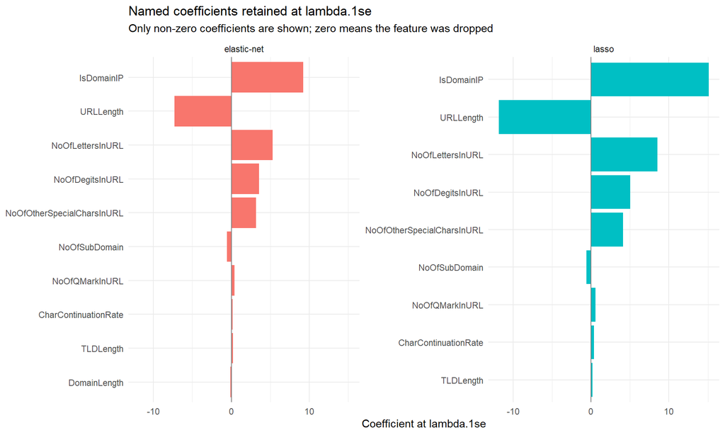

```r
coef_at_lambda <- function(cvfit, label, s = "lambda.1se") {
  beta <- as.matrix(coef(cvfit, s = s))[-1, , drop = FALSE]
  tibble(
    predictor = rownames(beta),
    method = label,
    coefficient = as.numeric(beta[, 1]),
    retained = coefficient != 0
  )
}

embedded_coefs <- bind_rows(
  coef_at_lambda(lexical_final$lasso_fit, "lasso"),
  coef_at_lambda(lexical_final$en_fit,    "elastic-net")
)

embedded_coefs %>%
  filter(retained) %>%
  mutate(predictor = reorder(predictor, abs(coefficient))) %>%
  ggplot(aes(coefficient, predictor, fill = method)) +
  geom_col(show.legend = FALSE) +
  facet_wrap(~ method, scales = "free_y") +
  geom_vline(xintercept = 0, colour = "grey50") +
  labs(
    title = "Named coefficients retained at lambda.1se",
    subtitle = "Only non-zero coefficients are shown; zero means the feature was dropped",
    x = "Coefficient at lambda.1se",
    y = NULL
  ) +
  theme_minimal()
```

```r
active_lambda_table <- function(cvfit, label) {
  beta_path <- as.matrix(coef(cvfit$glmnet.fit))[-1, , drop = FALSE]
  lambdas <- cvfit$glmnet.fit$lambda

  beta_path %>%
    as_tibble(rownames = "predictor") %>%
    rename_with(~ as.character(seq_along(lambdas)), -predictor) %>%
    pivot_longer(-predictor, names_to = "lambda_index", values_to = "coefficient") %>%
    mutate(lambda = lambdas[as.integer(lambda_index)]) %>%
    filter(coefficient != 0) %>%
    summarise(active_lambda = max(lambda), .by = predictor) %>%
    right_join(tibble(predictor = rownames(beta_path)), by = "predictor") %>%
    mutate(method = label) %>%
    select(predictor, active_lambda, method) %>%
    arrange(desc(active_lambda))
}

embedded_lambda <- bind_rows(
  active_lambda_table(lexical_final$lasso_fit, "lasso"),
  active_lambda_table(lexical_final$en_fit,    "elastic-net")
)

embedded_lambda %>%
  pivot_wider(names_from = method, values_from = active_lambda) %>%
  mutate(across(c(lasso, `elastic-net`),
                ~ if_else(is.na(.x), "(never)", as.character(signif(.x, 3))))) %>%
  arrange(predictor) %>%
  kable(caption = "Largest lambda at which each predictor is active. Larger = retained under stronger regularisation.")
```

Largest lambda at which each predictor is active. Larger = retained under stronger regularisation.

| predictor | lasso | elastic-net |
| --- | --- | --- |
| CharContinuationRate | 0.00253 | 0.358 |
| DomainLength | 0.000628 | 0.0135 |
| IsDomainIP | 0.00359 | 0.00333 |
| NoOfAmpersandInURL | (never) | (never) |
| NoOfDegitsInURL | 0.135 | 0.411 |
| NoOfEqualsInURL | (never) | (never) |
| NoOfLettersInURL | 0.0179 | 0.252 |
| NoOfObfuscatedChar | (never) | (never) |
| NoOfOtherSpecialCharsInURL | 0.272 | 0.543 |
| NoOfQMarkInURL | 0.00253 | 0.00235 |
| NoOfSubDomain | 0.0673 | 0.135 |
| TLDLength | 0.0385 | 0.0625 |
| URLLength | 0.00628 | 0.0102 |

In this run lasso and stepwise converge on the **same 9 features**: `URLLength`, `NoOfLettersInURL`, `NoOfDegitsInURL`, `NoOfOtherSpecialCharsInURL`, `NoOfSubDomain`, `NoOfQMarkInURL`, `CharContinuationRate`, `TLDLength` and `IsDomainIP`. Two completely different selection mechanisms agreeing on the same support is a strong consistency signal for the lexical URL filter.

Elastic-net adds only `DomainLength` on top of that 9-feature core. It is correlated with the URL / letter-count features, so this is the expected elastic-net behaviour: it keeps one extra member of the correlated length group where lasso and stepwise stay at the stricter 9-feature support.

# 7. Secondary FullLite stress test for FS methods

We evaluate the Lexical pool on a single 80/20 hold-out. H2 asks whether the AUC / Sensitivity / Specificity thresholds are met, and with only 13 features dominated by a URL-length signal the selected support is stable. Extra folds would only add noise around a clear result. On FullLite we are not looking at operational quality (which is near-perfect for all three methods on this pool) but **how many features each method keeps and how stable that count is**. With 34 mixed-tier candidates a single fit gives one number per method. The 10-fold turns that into a *distribution of selected-predictor counts*.

We reuse the Scenario 2 preprocessing to keep the comparison consistent.

```r
perfold <- run_or_load("perfold", function() {
  t0 <- Sys.time()

  fit_fold <- function(rows, k) {
    trn <- train_std %>%
      slice(rows) %>%
      select(label, all_of(predictors))

    cat(sprintf("  fold %2d: fitting stepwise / lasso / EN...\n", k))
    flush.console()

    sw   <- fit_stepwise(trn, predictors)
    sw_terms <- setdiff(names(coef(sw)), "(Intercept)")

    cvl <- fit_glmnet(trn, alpha = 1)
    lasso_names <- colnames(model.matrix(label ~ . - 1, data = trn))
    lasso_terms <- selected_glmnet_terms(cvl, lasso_names)

    cve <- fit_glmnet(trn, alpha = 0.5)
    en_terms <- selected_glmnet_terms(cve, lasso_names)

    cat(sprintf("  fold %2d done: step=%2d  lasso=%2d  EN=%2d\n",
                k, length(sw_terms), length(lasso_terms), length(en_terms)))
    flush.console()

    tibble(
      fold = k,
      k_step = length(sw_terms),
      k_lasso = length(lasso_terms),
      k_en = length(en_terms),
      step_terms = list(sw_terms),
      lasso_terms = list(lasso_terms),
      en_terms = list(en_terms)
    )
  }

  fold_results <- map2_dfr(fold_idx, seq_along(fold_idx), fit_fold)
  elapsed <- as.numeric(difftime(Sys.time(), t0, units = "secs"))

  list(k_step = fold_results$k_step,
       k_lasso = fold_results$k_lasso,
       k_en = fold_results$k_en,
       step_terms = fold_results$step_terms,
       lasso_terms = fold_results$lasso_terms,
       en_terms = fold_results$en_terms,
       elapsed_secs = elapsed)
})

tibble(
  fold = seq_along(fold_idx),
  k_step  = perfold$k_step,
  k_lasso = perfold$k_lasso,
  k_en    = perfold$k_en
) %>%
  kable(caption = "FullLite stress test: selected-predictor count per CV fold (out of 34 candidates).")
```

FullLite stress test: selected-predictor count per CV fold (out of 34 candidates).

| fold | k_step | k_lasso | k_en |
| --- | --- | --- | --- |
| 1 | 17 | 23 | 25 |
| 2 | 17 | 23 | 25 |
| 3 | 17 | 23 | 25 |
| 4 | 16 | 22 | 25 |
| 5 | 18 | 23 | 25 |
| 6 | 19 | 23 | 25 |
| 7 | 20 | 25 | 25 |
| 8 | 17 | 22 | 25 |
| 9 | 18 | 23 | 25 |
| 10 | 17 | 22 | 24 |

```r
mean_step  <- mean(perfold$k_step)
mean_lasso <- mean(perfold$k_lasso)
mean_en    <- mean(perfold$k_en)

tibble(
  metric = c("mean k (stepwise)", "mean k (lasso)", "mean k (elastic-net)"),
  value  = c(sprintf("%.1f", mean_step),
             sprintf("%.1f", mean_lasso),
             sprintf("%.1f", mean_en))
) %>% kable(caption = "Average selected-predictor count across folds for each FS method.")
```

Average selected-predictor count across folds for each FS method.

| metric | value |
| --- | --- |
| mean k (stepwise) | 17.6 |
| mean k (lasso) | 22.9 |
| mean k (elastic-net) | 24.9 |

The boxplot below complements the table by showing the **distribution of selected-predictor counts across the folds**. The position of each box on the y-axis indicates how aggressively a method shrinks the pool, while its height reflects whether the method keeps a similar count regardless of the fold. The dashed line marks the full FullLite as a reference ceiling.

**Stepwise** sits clearly lowest but also has the widest spread, ranging from 16 to 20 predictors, so it is the most aggressive but the least stable of the three. **Elastic-net** sits highest and is almost constant at 25 predictors, with one fold at 24. **Lasso** lands in between, mostly around 22-23 predictors with one fold reaching 25. None of the methods come close to the 34-predictor ceiling, so all three perform meaningful reduction.

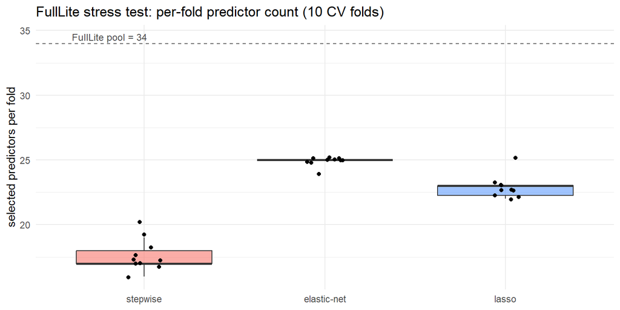

```r
perfold_long <- tibble(
  fold = seq_along(fold_idx),
  stepwise = perfold$k_step,
  lasso = perfold$k_lasso,
  `elastic-net` = perfold$k_en
) %>%
  pivot_longer(-fold, names_to = "method", values_to = "k") %>%
  mutate(method = factor(method, levels = c("stepwise", "elastic-net", "lasso")))

ggplot(perfold_long, aes(method, k, fill = method)) +
  geom_boxplot(alpha = 0.6, outlier.shape = NA) +
  geom_point(position = position_jitter(width = 0.1, seed = 1), size = 1.4) +
  geom_hline(yintercept = length(predictors), linetype = "dashed", colour = "grey40") +
  annotate("text", x = 0.6, y = length(predictors) + 0.5,
           label = sprintf("FullLite pool = %d", length(predictors)),
           hjust = 0, size = 3.2, colour = "grey30") +
  labs(x = NULL, y = "selected predictors per fold",
       title = "FullLite stress test: per-fold predictor count (10 CV folds)") +
  theme_minimal() + theme(legend.position = "none")
```

## 7.2 Selection frequency across folds

Instead of reading off a single fit, we count for each FullLite predictor how many of the 10 folds each FS method retained it. Predictors selected in all 10 folds are the robust “core” of the FullLite support, predictors selected only occasionally are weaker or correlated.

```r
n_folds <- length(fold_idx)

count_in_folds <- function(term_lists, term) {
  sum(map_lgl(term_lists, ~ term %in% .x))
}

all_fulllite_terms <- sort(unique(c(
  flatten_chr(perfold$step_terms),
  flatten_chr(perfold$lasso_terms),
  flatten_chr(perfold$en_terms),
  predictors
)))

d1_full <- tibble(
  predictor   = all_fulllite_terms,
  stepwise    = map_int(predictor, ~ count_in_folds(perfold$step_terms, .x)),
  lasso       = map_int(predictor, ~ count_in_folds(perfold$lasso_terms, .x)),
  elastic_net = map_int(predictor, ~ count_in_folds(perfold$en_terms, .x))
) %>%
  mutate(score = stepwise + lasso + elastic_net) %>%
  arrange(desc(score), predictor) %>%
  dplyr::select(-score)

d1_full %>%
  kable(caption = sprintf(
    "FullLite predictors: number of CV folds (out of %d) in which each FS method retained each predictor. Higher = more robust to resampling.",
    n_folds))
```

FullLite predictors: number of CV folds (out of 10) in which each FS method retained each predictor. Higher = more robust to resampling.

| predictor | stepwise | lasso | elastic_net |
| --- | --- | --- | --- |
| DomainLength | 10 | 10 | 10 |
| HasCopyrightInfo | 10 | 10 | 10 |
| HasDescription | 10 | 10 | 10 |
| HasFavicon | 10 | 10 | 10 |
| HasHiddenFields | 10 | 10 | 10 |
| HasSocialNet | 10 | 10 | 10 |
| HasSubmitButton | 10 | 10 | 10 |
| HasTitle | 10 | 10 | 10 |
| IsHTTPS | 10 | 10 | 10 |
| NoOfDegitsInURL | 10 | 10 | 10 |
| NoOfEmptyRef | 10 | 10 | 10 |
| NoOfLettersInURL | 10 | 10 | 10 |
| IsResponsive | 7 | 10 | 10 |
| NoOfOtherSpecialCharsInURL | 5 | 10 | 10 |
| Pay | 5 | 10 | 10 |
| NoOfiFrame | 4 | 10 | 10 |
| NoOfPopup | 3 | 10 | 10 |
| NoOfSubDomain | 1 | 10 | 10 |
| NoOfURLRedirect | 1 | 10 | 10 |
| Robots | 1 | 10 | 10 |
| Crypto | 0 | 10 | 10 |
| TLDLength | 1 | 8 | 10 |
| IsDomainIP | 0 | 9 | 9 |
| CharContinuationRate | 5 | 0 | 10 |
| HasPasswordField | 3 | 1 | 10 |
| LargestLineLength | 10 | 1 | 0 |
| URLLength | 10 | 0 | 0 |
| Bank | 0 | 0 | 0 |
| HasExternalFormSubmit | 0 | 0 | 0 |
| NoOfAmpersandInURL | 0 | 0 | 0 |
| NoOfEqualsInURL | 0 | 0 | 0 |
| NoOfObfuscatedChar | 0 | 0 | 0 |
| NoOfQMarkInURL | 0 | 0 | 0 |
| NoOfSelfRedirect | 0 | 0 | 0 |

**A universal core of 12 predictors** is retained 10/10 by every method - `DomainLength`, `IsHTTPS`, the URL counts (`NoOfLettersInURL`, `NoOfDegitsInURL`, `NoOfEmptyRef`) and the HTML `Has*` flags. These are the signal all three methods agree on. **Stepwise and the regularised methods disagree on correlated or weaker predictors**: stepwise keeps `URLLength` 10/10 while lasso and elastic-net drop it in every fold; lasso/EN keep `Crypto` and `NoOfURLRedirect` 10/10 while stepwise almost never uses them. `IsDomainIP` is mostly a regularised-model feature (9/10 for lasso and EN, 0/10 for stepwise). Seven candidates were never selected by any method: `Bank`, `HasExternalFormSubmit`, `NoOfAmpersandInURL`, `NoOfEqualsInURL`, `NoOfObfuscatedChar`, `NoOfQMarkInURL` and `NoOfSelfRedirect`.

# 8. Conclusion

The primary Lexical URL-only result supports the project story. Stepwise and lasso reduce the deployable URL filter from 13 predictors to **9 each** (elastic-net to 10), and the reduced fits meet the explicit AUC >= 0.95, Sensitivity >= 0.94 and Specificity >= 0.75 thresholds: stepwise (AUC 0.957 / Sens 0.949 / Spec 0.839) clears all three by a comfortable margin, lasso (0.952 / 0.941 / 0.764) clears them tightly. Elastic-net is close but does not pass the H2 thresholds in this run.

FullLite is treated as a sparsity-stress test only so the question was *how compactly* each method gets there. All three agree on a 12-predictor core, the extra width of lasso/EN comes from weak or correlated predictors that stepwise drops but L1/L2 keeps. The smallest feature set comes from stepwise. Lasso and elastic-net are still useful, but on this pool they do not pick fewer predictors than stepwise.